# Exploratory Data ANalysis of 2016 Presidential Election Contributions in Illinois

Now we plot contributed amounts per capita.

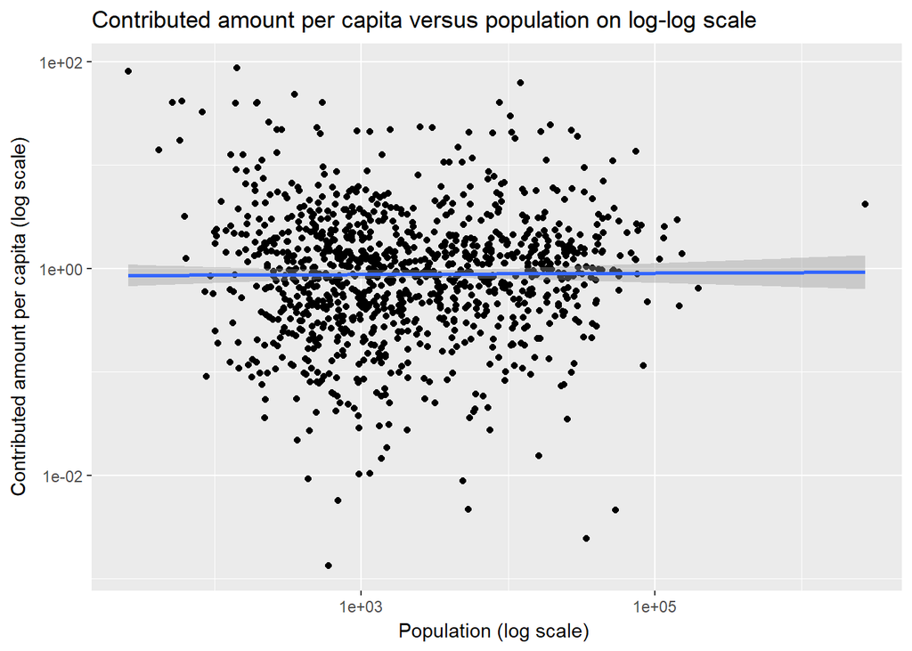

The scatter plot here is a cloud that shows no correlation between population and the amount per capita.

```
## [1] "correlation between population and mean of contribtions"
```

```
## [1] 0.004401037
```

```
## correlation between log transformed of both population and mean of contribtions
```

```
## [1] 0.1013919
```

As we see that correlation are extremely week or nonexistent.

Lets look at relation between total contributed amounts and the number of contributions per place.

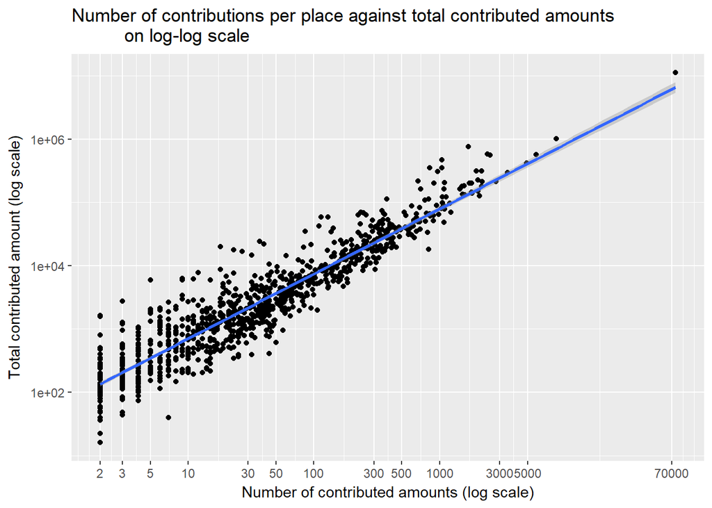

We observe that places that contributed few times, had a great deal of variability in the total amount it contributed. As the number of contributions increased the variability seams to be less. A linear fit seam to be reasonable here.

```
## Correlation between the log of number of contributions and log total amount is 0.9321818
```

```
##
##
##  Linear least squares regression model
```

```
##
## Call:
## lm(formula = log10(total_amt) ~ log10(n), data = subset(contb_by_city,
##     (population < 5e+06) & (population > 0) & log10(n) > 0))
##
## Residuals:
##      Min       1Q   Median       3Q      Max
## -1.09070 -0.19918 -0.02458  0.17147  1.23307
##
## Coefficients:
##             Estimate Std. Error t value Pr(>|t|)
## (Intercept)  1.82091    0.02173   83.79   <2e-16 ***
## log10(n)     1.02520    0.01267   80.94   <2e-16 ***
## ---
## Signif. codes:  0 '***' 0.001 '**' 0.01 '*' 0.05 '.' 0.1 ' ' 1
##
## Residual standard error: 0.3157 on 988 degrees of freedom
## Multiple R-squared:  0.869,  Adjusted R-squared:  0.8688
## F-statistic:  6552 on 1 and 988 DF,  p-value: < 2.2e-16
```

The least square fit here shows a strong association and explains 86% of the variation in the total contributed amount.

#### location versus contribution

Here is a plot of all places(cities, villages and towns) that made a contribution.

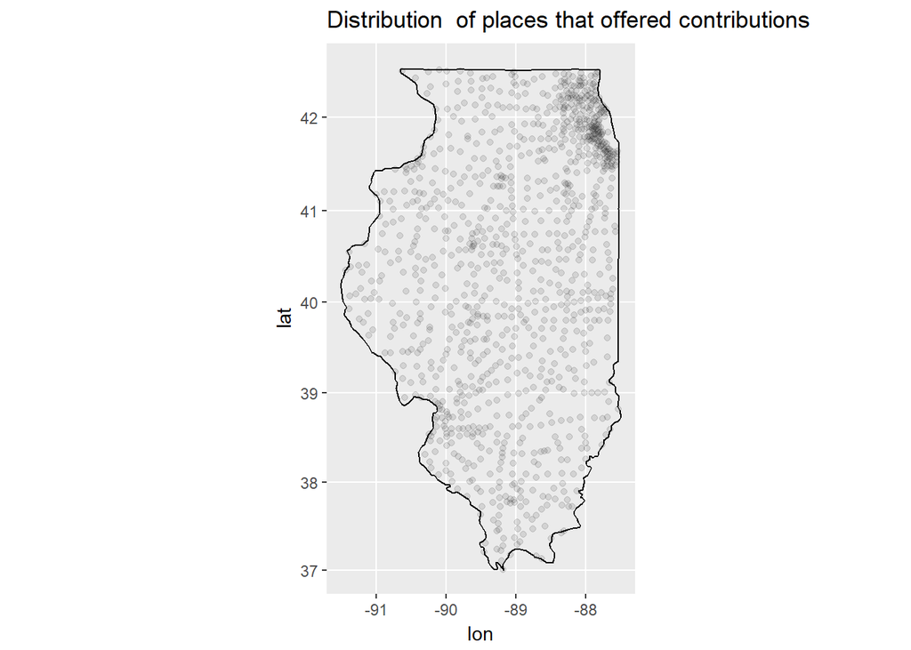

we know that most contributions are small. The question now is where did large contributions come from . The following map show the location of places that made contributions over $200. As you see the map is less dense but yet they are scattered every where.In particular, not any seem close to main cities in the state, we may conclude most these came from rural areas.

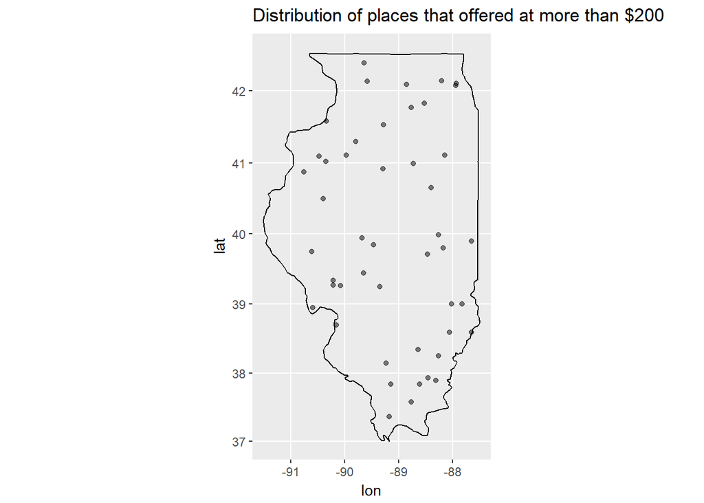

As you see the map is less dense but yet they are scattered every where.In particular, not any seem close to main cities in the state, we may conclude most these came from rural areas. Lets verify this by looking at a summary of populations of these places.

```
## Summary of population of places that offered more than $200
```

```
##    Min. 1st Qu.  Median    Mean 3rd Qu.    Max.
##     0.0     0.0    26.0  1127.8   502.8 54167.0
```

```
##
## Percentiles of the population of places that offered more than $200
```

```
##      85%      90%      95%      97%      99%
##   864.05  1129.80  2693.65  3957.78 18909.77
```

The summary shows that 75% of these places have a population less than 503. Even 95% of these places have a population less that 2700. So they are mostly rural.

## Multivariate plots

In this section I intend to look at contributions over time, as well as interaction between several of the variables I explored above.

First, I explore the amount contributed over time for the main parties.

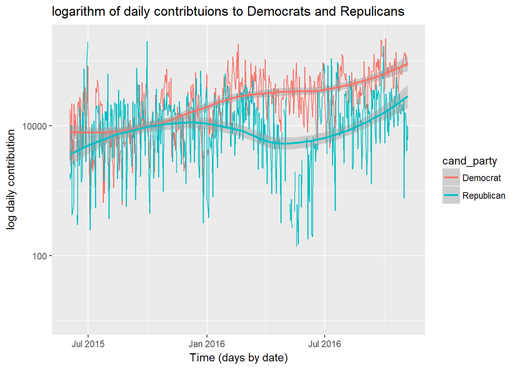

We observe considerable fluctuations over time in daily contribution for both parties. The Democrats received more contribution on a daily basis except around October of 2015.

Lets look at the mean amount received each day.

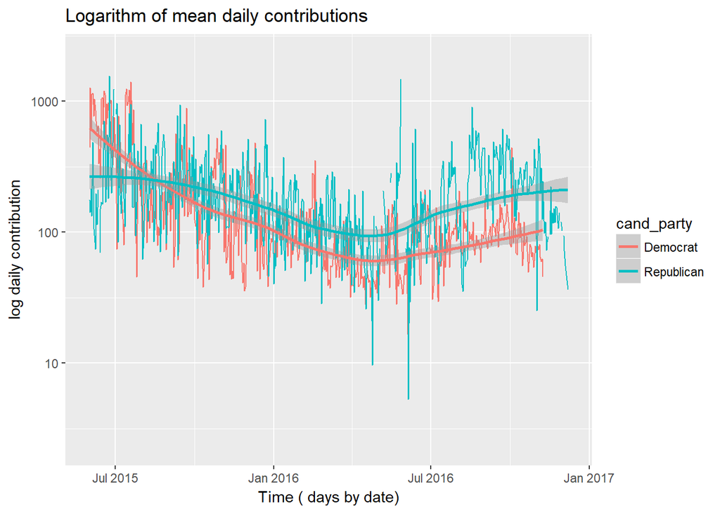

We observe from the above plots that Democrats had higher daily contributions. But the average daily contribution of the Republicans was higher on the other hand.

We wish to smooth the fluctuations in the graph. Therefore, we consider a moving average over 7 days.

```
## # A tibble: 6 x 4
##   `as.Date(contb_date)` daily_sum date           n
##   <date>                    <dbl> <date>     <int>
## 1 2013-10-04                   0  2013-10-04     2
## 2 2013-12-04                   0  2013-12-04     2
## 3 2014-08-14                 250  2014-08-14     1
## 4 2014-08-19                1000  2014-08-19     1
## 5 2014-09-22                2850  2014-09-22     2
## 6 2014-09-29                 202. 2014-09-29     1
```

```
## # A tibble: 7 x 5
##   `as.Date(contb_date)` daily_sum date           n   mav
##   <date>                    <dbl> <date>     <int> <dbl>
## 1 2015-05-01                 350  2015-05-01     2  175
## 2 2015-05-02                 300  2015-05-02     1  217.
## 3 2015-05-03                  20  2015-05-03     1  168.
## 4 2015-05-04               10612. 2015-05-04    41  251.
## 5 2015-05-05               54330  2015-05-05    53  670.
## 6 2015-05-06                2575  2015-05-06    14  609.
## 7 2015-05-07                2600  2015-05-07    16  553.
```

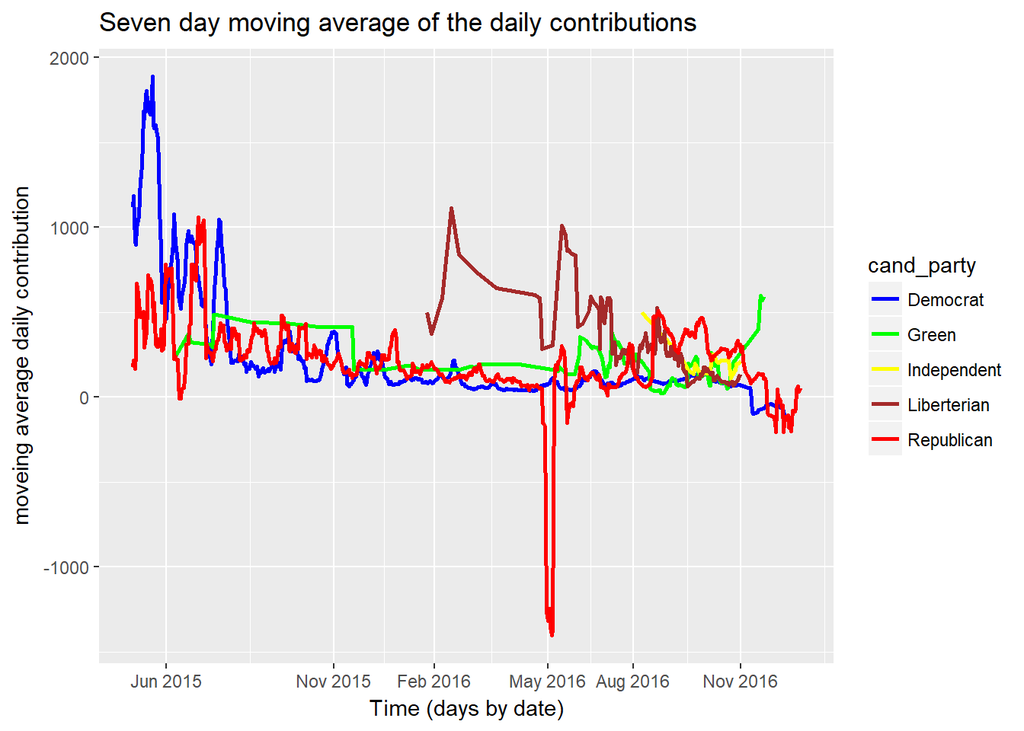

Observe the huge spike for the Democrats, in May 2015, and for the Libertarian in February and May of 2016. We recall that the frequency of contributions were low in May and June 2015, thus these spikes for the Democrats are more likely due to large amounts and not many small amount that would have averaged there effect out. We also observe the huge drop for the Republicans, reflecting huge refund. This coincides with Cruz dropping out of the race. On average we see that the daily contributions of the Republicans and Democrats are similar from August 2015 to August 2016.

We zoom -in on the period between 1 Jun 2016 and 25 Dec 2016, to look more closely on what went on during that time period.

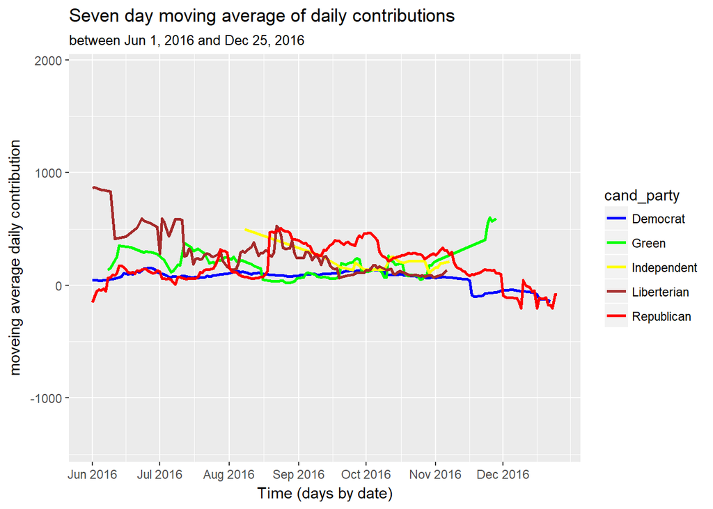

We see the 7 day moving average picked up for democrats between Aug and Nov, then came the refunds surge after the elections. For the republicans the average contributions seems stable up to elections day followed by refunds. The Green party seems to be stable with more contributions after the elections, the only party to have experienced this. The Libertarian party had the highest contributions up to September, then slowed down, but no refund after elections. The Independent candidate starts receiving considerable contributions in August up to elections, but no refunds.

In the graph below we look at each party separately.

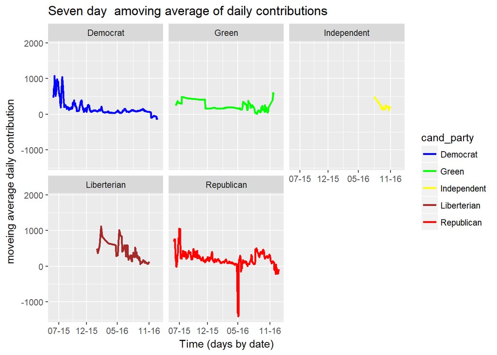

I am curious about refund dates of the two major parties

```r
contrib_Dem.df$date[contrib_Dem.df$amount<=0]
```

```
##  [1] 2016-05-01 2016-11-09 2016-11-10 2016-11-11 2016-11-14 2016-11-15
##  [7] 2016-11-16 2016-11-17 2016-11-18 2016-11-21 2016-11-22 2016-11-23
## [13] 2016-11-28 2016-11-29 2016-11-30 2016-12-05 2016-12-09 2016-12-10
## [19] 2016-12-14 2016-12-16 2016-12-17 2016-12-20 2016-12-22
## 601 Levels: 2014-12-06 2015-04-08 2015-04-12 2015-04-13 ... 2016-12-22
```

We see that for the Democrats, refunds came after election day

```r
contrib_Repub.df$date[contrib_Repub.df$amount<=0]
```

```
##  [1] 2013-10-04 2013-12-04 2015-03-31 2015-06-12 2015-07-01 2015-11-16
##  [7] 2015-12-17 2016-04-27 2016-05-04 2016-05-06 2016-05-13 2016-05-14
## [13] 2016-05-17 2016-05-29 2016-06-01 2016-07-02 2016-07-03 2016-11-15
## [19] 2016-11-28 2016-12-01 2016-12-09 2016-12-10 2016-12-16 2016-12-17
## [25] 2016-12-21 2016-12-22 2016-12-24
## 677 Levels: 2013-10-04 2013-12-04 2014-08-14 2014-08-19 ... 2016-12-31
```

For Republicans, refunds were at various times. Some as early as March 2015. Some even earlier in October 2013.

Now we turn attention to interaction between contributed amounts, party and population.

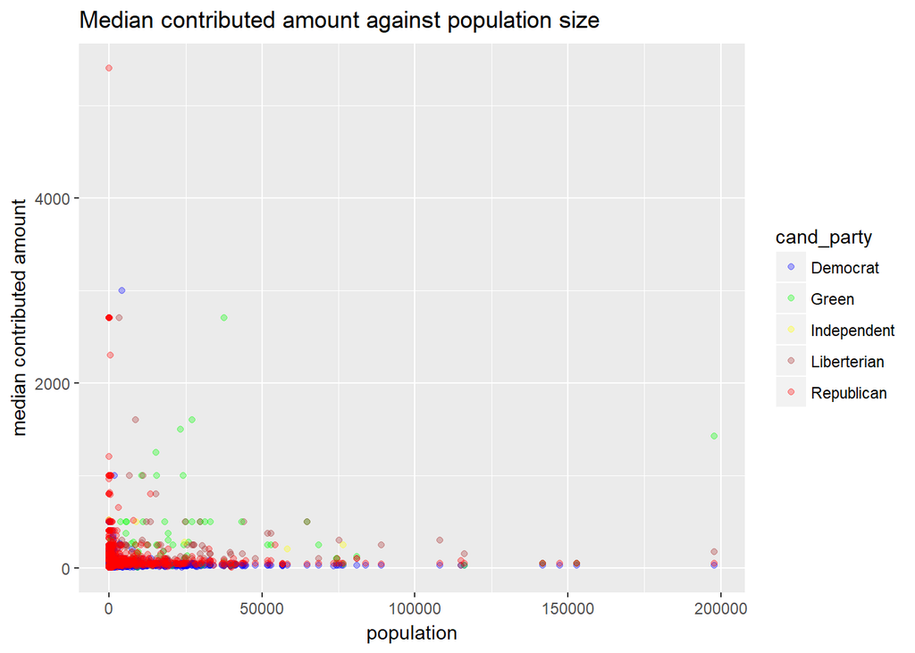

The Republican red contributions overlaps the Democrat blue marker, so we need a better view by using the log scale.

Observe the high median contribution to the Green party.

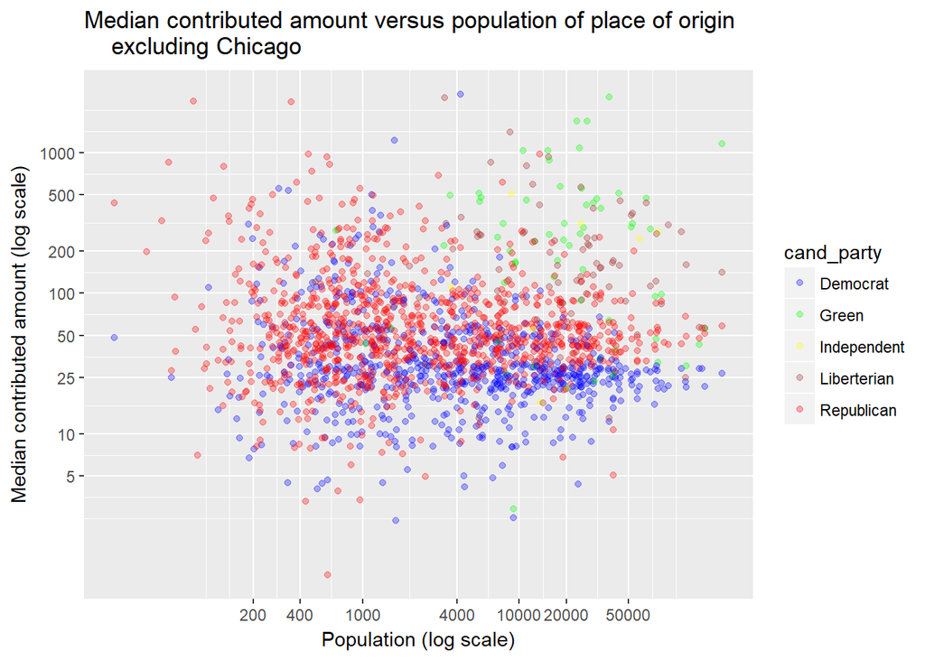

Here we see that the Democrats and Republicans had contributions from all place sizes across the board. We also see that the Democrat median contributions are smaller than that of the Republicans. The Republican median is mostly less than the Green and Libertarian. Also observe, contributions to the Democrats from places that are over 4000 in size tend to be small.

Obviously there is no association between population size and the median contributed amount. Therefore, I would like to find a least square regression model using party and the logarithm of population to predict the logarithm of total contributions from a place with a given population. First, lets look at the following plot:

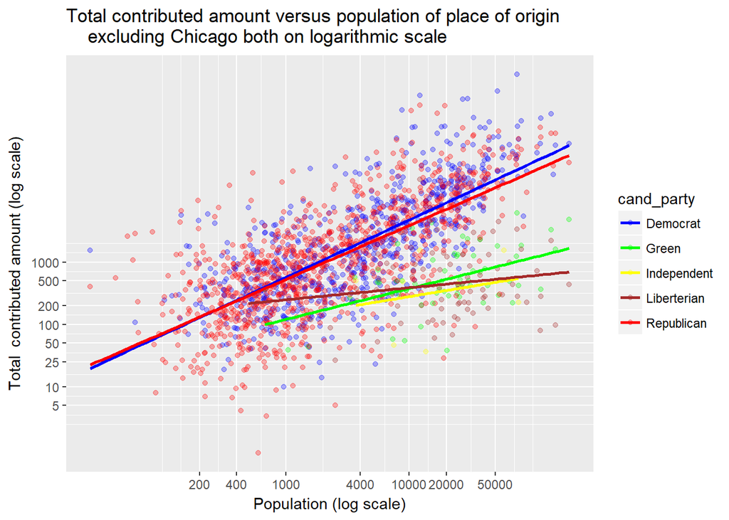

The plot suggests that the slopes of the lines depend on the party. Notice how the Democrats’ slope just slightly higher than the Republicans’; while the others have much smaller slopes and all three are different. Therefor when we model, we choose to consider the interaction terms only.

Recall in the previous section we also found a strong association with the number of contributions per place. We want to explore the interaction with parties.

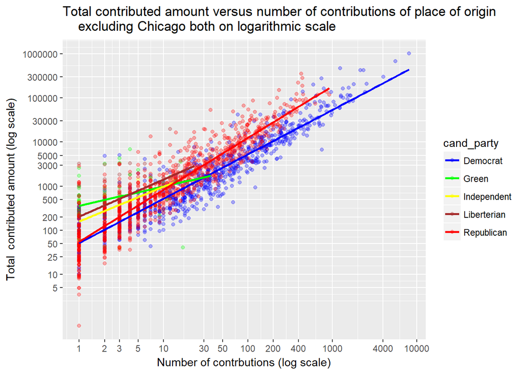

We are now ready to find a linear regression fit for the interaction of population size and number of contributions with parties. All continuous variables are log transformed.

```
##
## Call:
## lm(formula = log10(total_amt) ~ log10(population):cand_party +
##     log10(n):cand_party, data = subset(contb_by_city_party, (population >
##     0)))
##
## Residuals:
##      Min       1Q   Median       3Q      Max
## -1.83324 -0.21797 -0.03189  0.18492  1.71547
##
## Coefficients:
##                                         Estimate Std. Error t value
## (Intercept)                              1.67094    0.04920  33.963
## log10(population):cand_partyDemocrat     0.02717    0.01985   1.369
## log10(population):cand_partyGreen        0.21499    0.01880  11.438
## log10(population):cand_partyIndependent  0.12874    0.03908   3.295
## log10(population):cand_partyLiberterian  0.15156    0.01781   8.512
## log10(population):cand_partyRepublican   0.02353    0.01950   1.207
## cand_partyDemocrat:log10(n)              0.97429    0.02334  41.752
## cand_partyGreen:log10(n)                 0.40390    0.10180   3.968
## cand_partyIndependent:log10(n)           0.77491    0.32411   2.391
## cand_partyLiberterian:log10(n)           0.81962    0.09968   8.222
## cand_partyRepublican:log10(n)            1.16774    0.02367  49.335
##                                         Pr(>|t|)
## (Intercept)                              < 2e-16 ***
## log10(population):cand_partyDemocrat      0.1713
## log10(population):cand_partyGreen        < 2e-16 ***
## log10(population):cand_partyIndependent   0.0010 **
## log10(population):cand_partyLiberterian  < 2e-16 ***
## log10(population):cand_partyRepublican    0.2276
## cand_partyDemocrat:log10(n)              < 2e-16 ***
## cand_partyGreen:log10(n)                7.53e-05 ***
## cand_partyIndependent:log10(n)            0.0169 *
## cand_partyLiberterian:log10(n)          3.65e-16 ***
## cand_partyRepublican:log10(n)            < 2e-16 ***
## ---
## Signif. codes:  0 '***' 0.001 '**' 0.01 '*' 0.05 '.' 0.1 ' ' 1
##
## Residual standard error: 0.3604 on 1903 degrees of freedom
## Multiple R-squared:  0.8351, Adjusted R-squared:  0.8342
## F-statistic: 963.6 on 10 and 1903 DF,  p-value: < 2.2e-16
```

The R-squared value reflects the model explains most of the variability in the total contributed amount at the log scale. Notice however, that population size for the Democrats and the Republican is not a significant factor as much as the number of contributions. While for the none-major parties both are important.

Next we look at spatial distribution for contributions above 100 dollars.

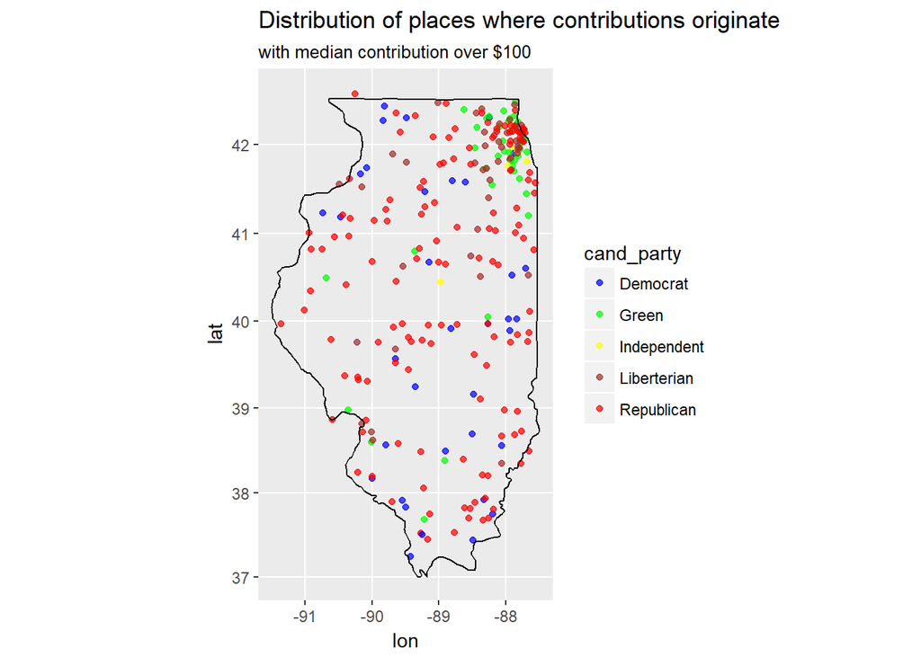

Observe the concentration in the north east, near Chicago area, for the Republican contributions and the Green contributions. Otherwise, the distribution is uniformly spread out for the all others, fewer Democrats than Republicans.

Lets look at small contribution distribution by party

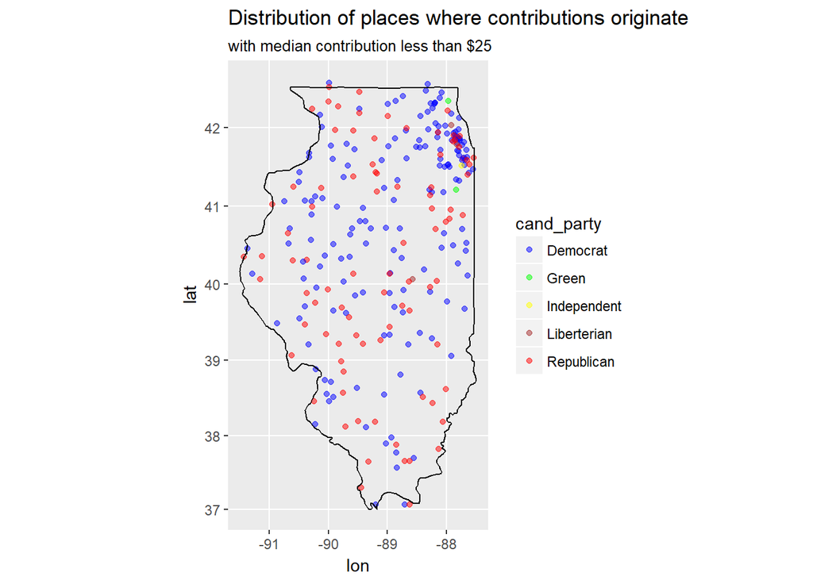

Now we see that most of these are for Democrats coming from the north east area which is highly populated. Small Republican contributions come of all over the state too but with less intensity.

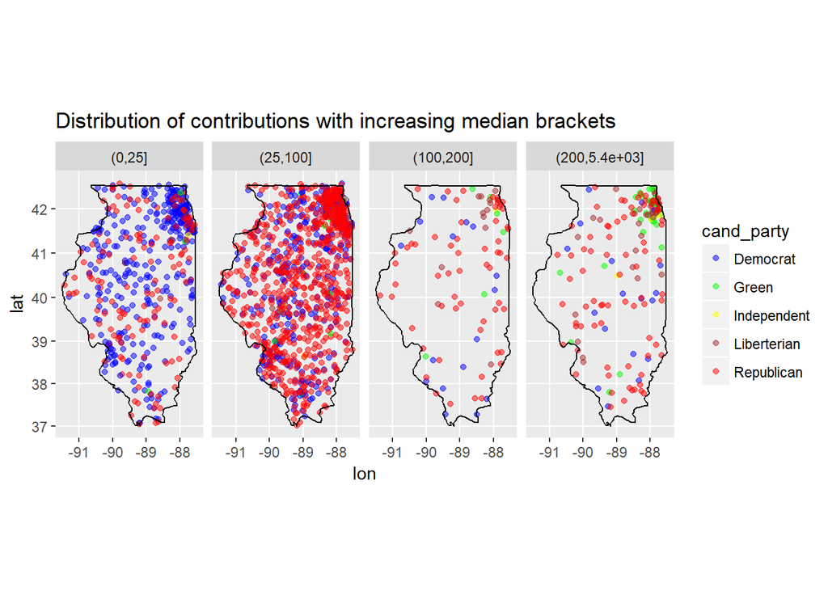

we see here the domination of Democrats in the first bracket, the Republican in the second we see more of the Green and the Libertarian in the upper brackets around larger cities in the north east region and other larger cities in the south , south west, and center slab.

# Final plots and Summary:

If I have to choose only three plots to highlight the findings of this data, I would necessarily choose a plot that reflects the frequency of contributions to candidates in the two elections types the primaries and the general. Specially in the 2016 elections, most people were favoring Sanders over Clinton for example but the party establishment pushed for Clinton instead.

I also want a plot that summarizes amount contributed to each party, this is the box plot.

The Third plot should be multivariate that reflects amounts contributed, parties and either time, population size, number of contributions or spatial distribution. I decided to go with time because it says something about the supporter’s response with time.

If I would choose a forth one I would choose the spacial distribution at four different brackets of amounts.In particular this plot shows how uniform is the support for Democrats and Republicans throughout the state with contributions dominated by the (0, 25], (25,100] brackets.

### Plot One

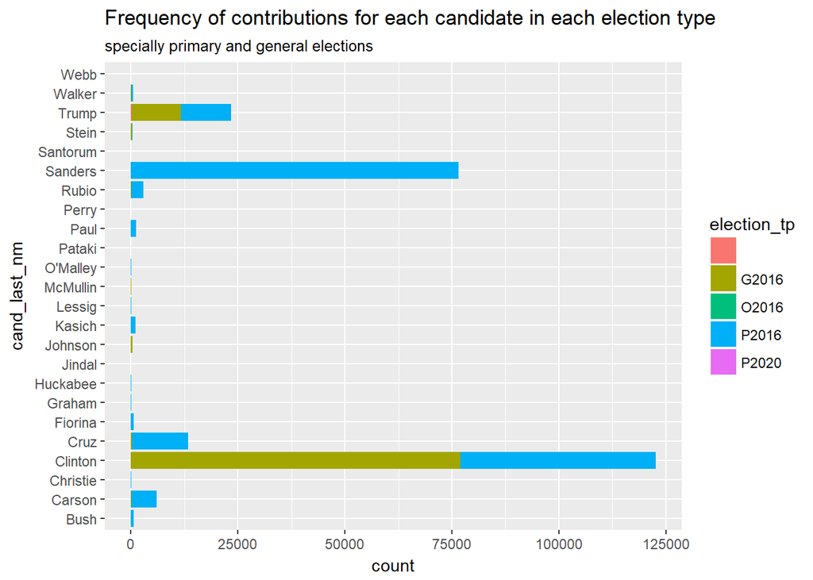

Here You see that most contributions went to Clinton and Sanders. Sanders had more contributions before the primaries. Among the Republicans,Trump and Cruz got the most contributions. Even though the number of contributions to Clinton increased after the primary assuming that she got some from Sanders supporter. We do not see this for Trump. The number of contribution to Trump stayed the same.

The number of contributions to the other none-major party candidates barely if any show up. Their numbers are very meager.

### Plot Two

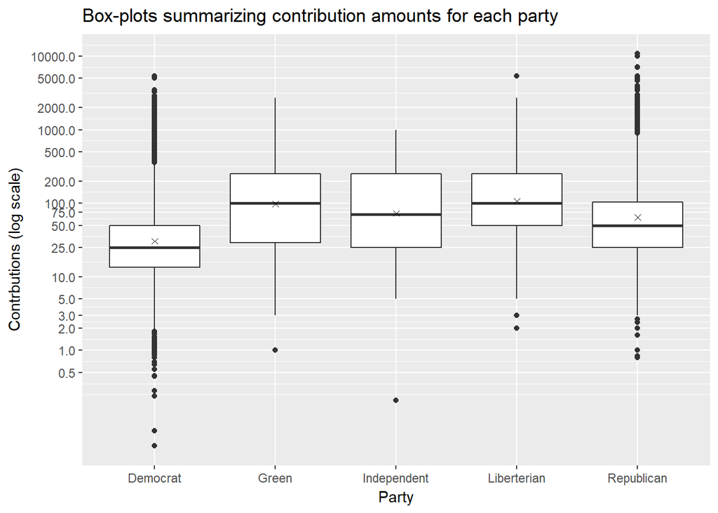

This box plot shows the general trend in contributions for each party. We observe that the Democratic party had the smallest median contributions. People contributed with as little as few cents it seems. But the Democrats also got some contributions over $1000 with a maximum of $5400. The bulk of their finance was contributions less than $50.

The Green party had their bulk of their contributions between $30 and $200, while the Libertarian party had it between $50 and $200.

The Independent candidate had their bulk of contributions between $25 to $200.

### Plot Three

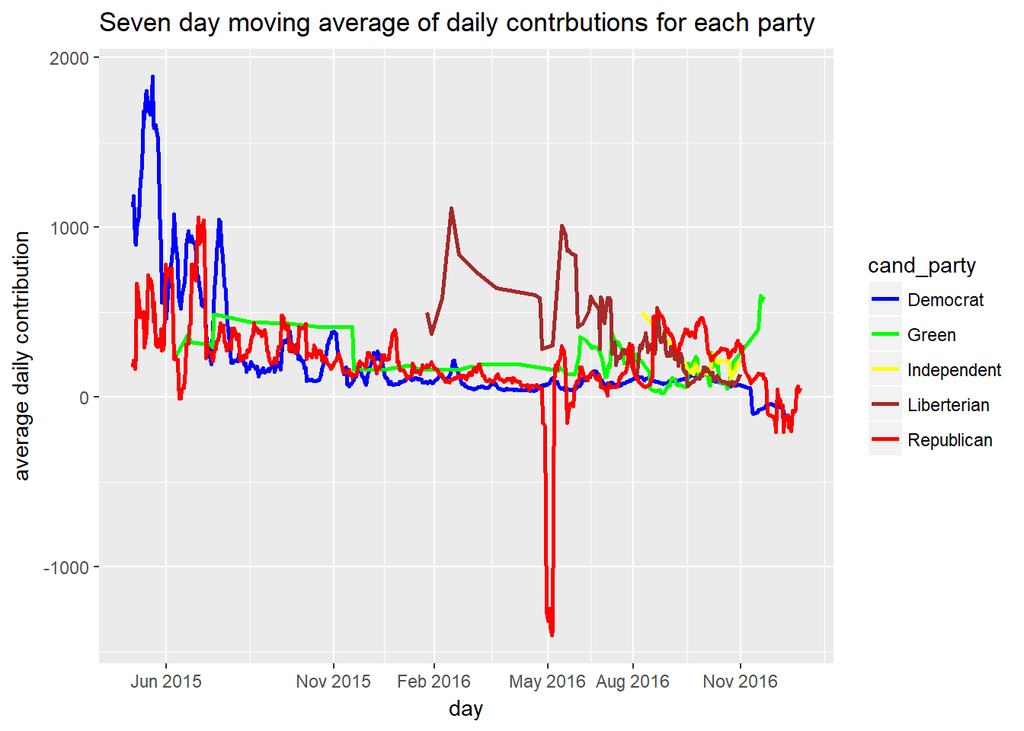

This plot shows contributions over time for each party. Notice that for the Democrats and Republicans, they received large amounts of contributions in June 2015, this is then followed by persistent stream of small contributions. The Democrats had an uptake near the general elections. Both parties were asked for refunds after the general elections.

The Libertarian party had their peak contributions in February and May and in general their average contributions where higher than any other party.

The Green party had no significant peak contributions, but two plateaus. The first form July 2015 to Dec 2015 is higher than the second from Dec 2015 to Jun 2016. Afterwards, pick up again till September 2016 and again after the elections are over.

The Independent candidate, started receiving contributions in August 2016. At this time the contributions where maximum and then start to decrease until the election day.

# Reflections:

In analyzing the Illinois contributions to the 2016 presidential elections, we found that the front runners in the Democratic party are Clinton and Sanders, among the Republican party are Cruz and Trump, with Carson and Rubio trailing behind. In much smaller numbers, there was support to the Green party and the Libertarian party as well as to the independent candidate. However overall most contributions went to the Democrats. Sanders had more supporters contributing to campaign before the primary elections. However, Clinton who is better known in Illinois, had more influence in general, plus being a woman with the prospect that she would be the first women president had lead I think to her receiving more contributions.

I chose to ignore the gender factor in this analysis. First, there are only three women. Two of them are leading in their own party and one of the two is well known. As I mentioned above, for Clinton both her gender and influence together played a major role in supporting her.

Contributions to the major parties tend to be small. However, we find that the variability is wider among the Republican supporters than Democrats. Supporters of non-major parties realized the need for larger contributions since these parties have low membership. The same applies to the independent candidate.

Contributions over time also varies. At the time when any of the parties starts receiving contributions, the average contributions are the highest, then tend to drop slightly and stabilize for a while. Some of the Republican’s and the Democrat’s contributions were refunded after the elections in November. The Green party is the only party that continued to gain contributions after the elections.

The population size of the city where the contribution originated, does not correlate with the average contribution be it mean or median. However we see that places with small population (less than 4000) show higher variability some small and some large contributions. We also notice that many contributions for the Green and Libertarian parties came from larger cities.

Obviously one would expect the number of contributions from a city will have an influence on the total contributions from that city, but not the median amounts.

We found that population size was not an important factor for the Democrats and Republicans in determining that total contributions from a particular place as much as the number of contributions from that place. For the none-major parties however, both factors were important, since they had much lower number of contributions mainly from high populated cities.

The spatial distribution of the contribution over the state do show first that they are not localized, there are uniformly distributed. However, when we take the median amount of the contributions we see complete agreement with box-plots of amounts contributed across parties.For up to $25 contributions are mainly for Democratic candidate, between $25 and $100 contributions are mainly for a Republican candidate. Contributions for the non-major parties show up when the median contribution exceed $100.

On the map I wish I could include the population size of the location of contribution. But I think will over crowd the map between color for party and size of the location.

Given my understanding of what goes in election public financing, I would be curious about how residents of Illinois contributed in past elections, how will they contribute in the next election in 2020. In particular, since there is disappointment with major parties leadership, one would be interested to see how attitude and contributions towards non-major parties will change if any.

Moreover, I ask whether contributions to gubernatorial elections 2018 will be similar or drastically different from presidential elections. This is because Illinois is leaning towards Democrats while the current Illinois governor is Republican. Of course there is context to this result in past gubernatorial elections yet one would wonder what happened on the contributions part of the story.